# Cross Correlation Analysis

question to consider here – this measures *linear* dependence, but I assume that okay given the curves will be highly linearly dependent if they are showing similar shapes.

# Defining Cross Correlation

Denote the set of time points of a time series $T$. For any time series $(x_t)_{t\in T}$, we define the auto-correlation function (ACF) as

$$\rho_{XX}(\tau) = \dfrac{E[(X_{t + \tau}
- \mu_{X_{t+\tau}}) (X_t - \mu_{X_t})]}{sd(X_{t+\tau})
sd(X_t)}.\tag{1}$$

Assuming second order stationarity[^1], we have $\mu_{X_{t+\tau}}=\mu_{X_{t}}$ and similarly $\text{Var}({X_{t+\tau}})=\text{Var}({X_{t}})$, so (1) simplifies to
$$=\dfrac{E[(X_{t +
\tau} - \mu_{X}) (X_t - \mu_{X})]}{Var(X)}$$
The auto-correlation function $\rho_{XX}(\tau)$ measures the linear dependence between $X_{1+\tau}, \dots X_n$ and $X_1, \dots, X_{n-\tau}$, that is, the difference between the original time series and the time series shifted forward by $\tau$ time units.

We can extend this definition to quantify the linear relationship between distinct lagged time series $X_1, X_2, \dots, X_t$ and $Y_1, Y_2, \dots, Y_t$ by defining the cross correlation function. The function is only defined on two time series that are over the same time interval and sampled at the same frequency. We compute the cross-correlation function (CCF) as

$$\rho_{XY}(s,t) = \dfrac{E[(X_s -
\mu_{X_s})(Y_t-\mu_{Y_t})]}{\sqrt{\text{Var}(X_s)
\text{Var}(Y_t)}}.$$
Again assuming the series satisfy second-order stationarity, we have

$$\rho_{XY}(s,t) = \dfrac{E[(X_s -
\mu_{X})(Y_t-\mu_{Y})]}{\sqrt{\text{Var}(X)
\text{Var}(Y)}}.$$

## Without Differencing

$z$ is $y$ lagged by 3 time units with some added noise. Without differencing, max correlation is not at -3.

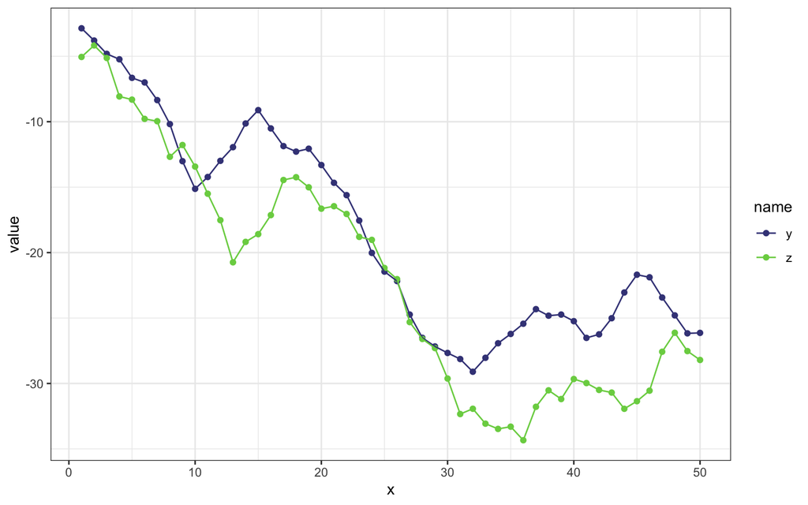

```r
library(tidyverse)

nsamp <- 50
lagged <- 3

# y is lagged 3 units behind z
set.seed(999)
y <-  as.numeric(arima.sim(list(order = c(1,1,0), ar = 0.7),
                           n = nsamp+lagged-1))
z <- lag(y,lagged)
z <- z[which(!is.na(z))]
z <- z + rnorm(length(z), -5, .5)
y <- y[(lagged+1):length(y)]

sim <- tibble(y = y,
              z= z,
              x = 1:length(y))

sim %>%
  pivot_longer(c(y,z)) %>%
  ggplot(aes(x=x, y = value, color = name)) +
  geom_point() +
  geom_line() +
  viridis::scale_color_viridis(discrete=TRUE, begin = .2, end = .8) +
  theme_bw()
```

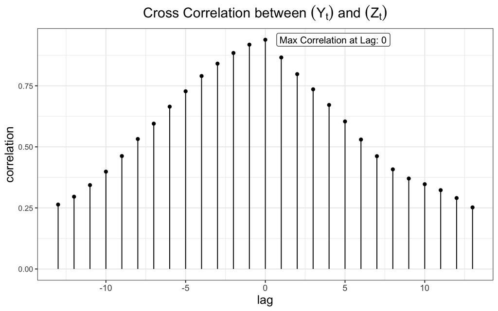

```r
res <- ccf(sim$y, sim$z, plot=FALSE)


ccf_res <- tibble(lag = res$lag[,,1], correlation=res$acf[,,1])

ccf_res %>%
  mutate(max = ifelse(correlation == max(correlation),
                      lag, NA)) %>%
  ggplot(aes(x=lag, y = correlation)) +
  geom_point() +
  geom_linerange(aes(ymin = 0, ymax=correlation)) +
  theme_c() +
  labs(title =TeX("Cross Correlation between $(Y_t)$ and $(Z_t)$")) +
  geom_label(aes(x = max, y = correlation,
                 label = paste0("Max Correlation at Lag: ", max)),
             hjust = -.1)
```

```r
##############################
# IMPLEMENTING FROM SCRATCH
##############################
autocorr <- function(lag_val, vec) {
  n <- length(vec)
  denom <- sum( (vec -mean(vec))  %*% (vec -mean(vec)) )
  num <- (vec[(lag_val+1):n] - mean(vec)) %*% (vec[1:(n-lag_val)] - mean(vec))
  as.numeric(num /denom)
}



# cross correlations between x and y, where x is lagged by lag_val units
crosscorr <- function(lag_val, x, y) {
  n <- length(x)
  var_x <- (sum( (x -mean(x))  %*% (x -mean(x)) ))
  var_y <- (sum( (y -mean(y))  %*% (y -mean(y))))
  denom <- sqrt(var_x*var_y)
  num <- (x[1:(n-lag_val)] - mean(x)) %*% (y[(lag_val+1):n] - mean(y))
  as.numeric(num /denom)
}

cross_all_pos <- map_df(0:12, ~{
  tibble(lag = .x,
         correlation =crosscorr(lag_val = .x,
                                 sim$z, sim$y))
})

cross_all_neg <- map_df(1:12, ~{
  tibble(lag = (-1)* .x,
         correlation = crosscorr(lag_val =.x,
                                 sim$y, sim$z))
})


cross_all <- bind_rows(cross_all_pos,
          cross_all_neg)

################################################
# compare implementation to stats implementation
################################################
cross_all %>%
   ggplot(aes(x=lag, y = correlation)) +
    geom_point() +
    geom_linerange(aes(ymin = 0, ymax=correlation)) +
    theme_c()
```

[output not shown]

```r
res <- ccf(sim$y, sim$z, plot = FALSE)


tibble(lag = res$lag[,,1], corr=res$acf[,,1]) %>%
  filter(corr==max(corr))
```

## With Differencing

$z$ is $y$ lagged by 3 time units with some added noise. With differencing, max correlation is at -3.

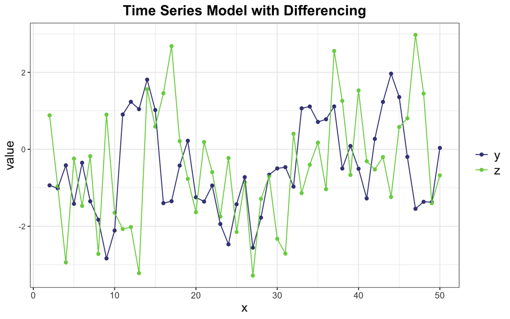

```r
library(tidyverse)



################################
# z is lagged 3 units behind y
################################
nsamp <- 50
lagged <- 3


set.seed(999)
y <-  as.numeric(arima.sim(list(order = c(1,1,0), ar = 0.7),
                           n = nsamp+lagged-1))
n <- length(y)

z <- y[1:(n-lagged)]
# add noise
z <- z + rnorm(length(z), -5, .5)
y <- y[(lagged+1):n]

# apply differencing
sim <- tibble(y = y -lag(y,1),
              z=  z - lag(z,1),
              x = 1:length(y)) %>%
  filter(!is.na(y))



sim %>%
  pivot_longer(c(y, z)) %>%
  ggplot(aes(x=x, y = value, color = name)) +
  geom_point() +
  geom_line() +
  viridis::scale_color_viridis(discrete=TRUE, begin = .2, end = .8) +
  theme_c() +
  labs(title ="Time Series Model with Differencing",
       color = "")
```

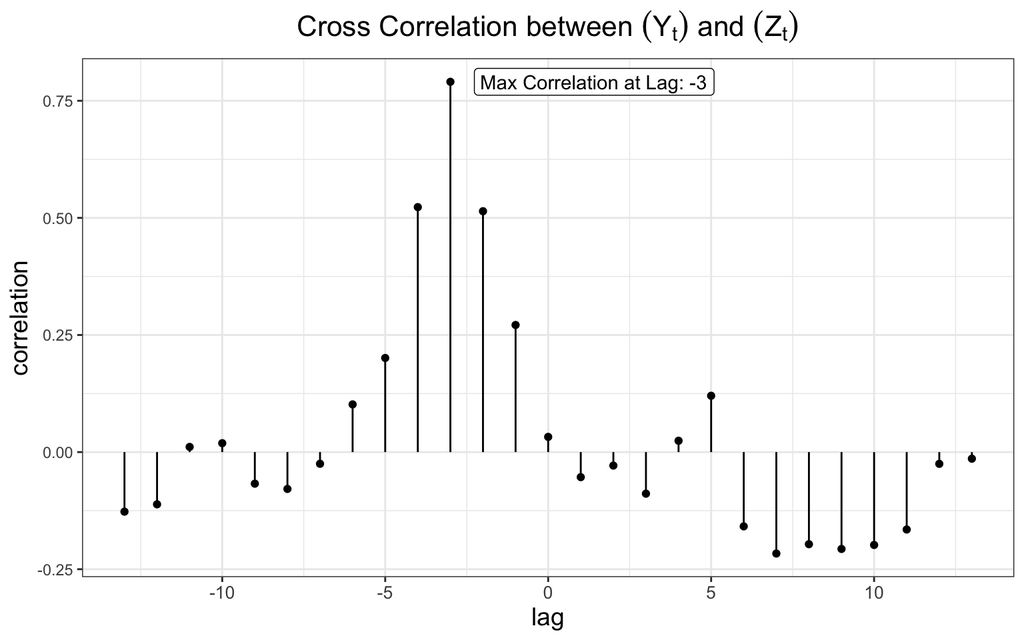

```r
res <- ccf(sim$y, sim$z, plot=FALSE)


tibble(lag = res$lag[,,1], correlation=res$acf[,,1]) %>%
  mutate(max = ifelse(correlation == max(correlation),
                      lag, NA)) %>%
  ggplot(aes(x=lag, y = correlation)) +
  geom_point() +
  geom_linerange(aes(ymin = 0, ymax=correlation)) +
  theme_c() +
  labs(title =TeX("Cross Correlation between $(Y_t)$ and $(Z_t)$")) +
  geom_label(aes(x = max, y = correlation,
                 label = paste0("Max Correlation at Lag: ", max)),
             hjust = -.1)
```

```r
autocorr <- function(lag_val, vec) {
  n <- length(vec)
  denom <- sum( (vec -mean(vec))  %*% (vec -mean(vec)) )
  num <- (vec[(lag_val+1):n] - mean(vec)) %*% (vec[1:(n-lag_val)] - mean(vec))
  as.numeric(num /denom)
}



# cross correlations between x and y, where x is lagged by lag_val units
crosscorr <- function(lag_val, x, y) {
  n <- length(x)
  var_x <- (sum( (x -mean(x))  %*% (x -mean(x)) ))
  var_y <- (sum( (y -mean(y))  %*% (y -mean(y))))
  denom <- sqrt(var_x*var_y)
  num <- (x[1:(n-lag_val)] - mean(x)) %*% (y[(lag_val+1):n] - mean(y))
  as.numeric(num /denom)
}


# split up due to implementation of crosscor function
# firt lag y
cross_all_pos <- map_df(0:12, ~{
  tibble(lag = .x,
         correlation =crosscorr(lag_val = .x,
                                 sim$z, sim$y))
})

cross_all_neg <- map_df(1:12, ~{
  tibble(lag = (-1)* .x,
         correlation = crosscorr(lag_val =.x,
                                 sim$y, sim$z))
})


cross_all <- bind_rows(cross_all_pos,
          cross_all_neg)

cross_all %>%
  mutate(max = ifelse(correlation == max(correlation),
                      lag, NA)) %>%
  ggplot(aes(x=lag, y = correlation)) +
  geom_point() +
  geom_linerange(aes(ymin = 0, ymax=correlation)) +
  theme_c() +
  geom_label(aes(x = max, y = correlation,
                 label = paste0("Max Correlation at Lag: ", max)),
             hjust = -.1)
```

[output not shown]

```r
#############################################
# IMPLEMENTATION FROM STATS
#############################################

res <- ccf(sim$y, sim$z)
```

[output not shown]

```r
# res <- tibble(acf =as.numeric(res$acf),
#               lag = as.numeric(res$lag))
# res %>% filter(acf==max(acf))

# cor(sim$y,sim$z)

tibble(lag = res$lag[,,1], corr=res$acf[,,1]) %>%
  filter(corr==max(corr))

tibble(lag = res$lag[,,1], corr=res$acf[,,1])
```

[^1]: Second order stationarity is also referred to as weak stationarity, and implies that the mean, variance are constant over time and the autocovariance function depends only on the difference between time points (i.e., the lag).